# Analysis of the Nominal Indo Pacific Ocean 2018 Data Set

Tallulah Coyte

23/11/2020

## Abstract

A dataset which collects records of catches (number of catches and specie of catch) by their gear type, which region of the Indo Pacific Ocean and which nationality vessel caught the fish.

## Cleaning the data

To start I’m going to observe the names of the columns and what they include to see if I need to rename or delete any.

```
##  [1] "FlSort"           "FlCde"            "Fleet"            "Flotte"
##  [5] "ArCde"            "AreaIOTC"         "ZoneCTOI"         "Year"
##  [9] "TFCde"            "TypeFishery"      "TypePêcherie"     "GrSort"
## [13] "GrCde"            "Gear"             "Engin"            "GrGroup"
## [17] "GrGroupe"         "GrMult"           "SpSort"           "SpCde"
## [21] "Species"          "Espèce"           "SpLat"            "SpGroup"
## [25] "SpGroupe"         "SpWP/SpGT"        "SpIOTC"           "SpMult"
## [29] "Catch/Capture(t)" "%EstGr"           "%EstSp"
```

The columns ‘Flotte’, ‘ZoneCTOI’, ‘TypePêcherie’, ‘Engin’, ‘GrGroupe’, ‘Espèce’ and ‘SpGroupe’ are simply french translations of each columns column to the left, this is because the Indo Pacific Ocean is home to French territories (islands of Mayotte and La Réunion, the Scattered Islands and the French Southern and Antarctic Territories). However, as this analysis is being conducted in English, I am going to remove these columns.

Now I’m going to plot the numerical classified variables to see if there are any outliers

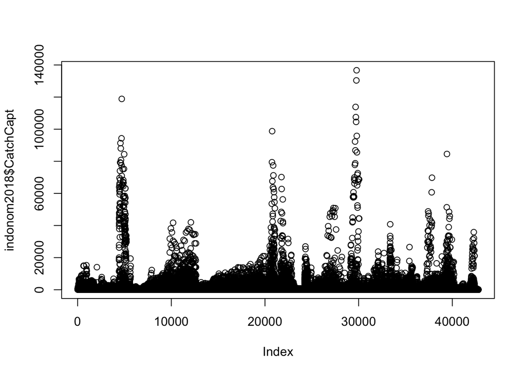

There seem to be no outliers in this variable.

## Number of catches against nationality.

First, I want to see how many different values there are in the variable ‘Fleet’, as this will tell us how diverse the vessels are in terms of nationalities.

```
##  [1] "UN. ARAB EMIRATES" "AUSTRALIA"         "BANGLADESH"
##  [4] "BAHRAIN"           "BELIZE"            "CHINA"
##  [7] "COMOROS"           "DJIBOUTI"          "EGYPT"
## [10] "ERITREA"           "EU.BULGARIA"       "EU.GERMANY"
## [13] "EU.SPAIN"          "EU.FRANCE"         "EU.UK"
## [16] "EU.ITALY"          "EU.FRANCE.MAYOTTE" "EU.PORTUGAL"
## [19] "EU.FRANCE.REUNION" "UK.TERRITORIES"    "GUINEA"
## [22] "INDONESIA"         "INDIA"             "IRAN ISLAMIC REP."
## [25] "ISRAEL"            "JORDAN"            "JAPAN"
## [28] "KENYA"             "KOREA REP."        "KUWAIT"
## [31] "SRI LANKA"         "MADAGASCAR"        "MALDIVES"
## [34] "MYANMAR"           "MOZAMBIQUE"        "MAURITIUS"
## [37] "MALAYSIA"          "NEI.FRESH"         "NEI.EEZ_INDONESIA"
## [40] "NEI.FROZEN"        "NEI.OTHER"         "NEI.EXSOVIET"
## [43] "OMAN"              "PAKISTAN"          "PHILIPPINES"
## [46] "QATAR"             "SAUDI ARABIA"      "SUDAN"
## [49] "SENEGAL"           "SOVIET UNION"      "SEYCHELLES"
## [52] "THAILAND"          "EAST TIMOR"        "TAIWAN,CHINA"
## [55] "TANZANIA"          "VANUATU"           "YEMEN"
## [58] "SOUTH AFRICA"
```

There are 58 different nationalities of vessels, which implies just by the sheer volume of foreign vessels that the ocean is rich in marine life. I am now going to plot the number of catches against nationality of the vessel.

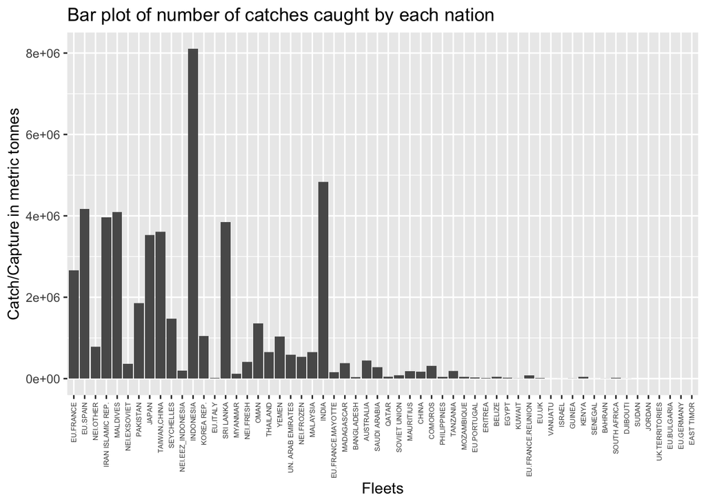

From this we can see that the nationalities that catch most fish in the Indo Pacific are: Indonesia, India, Spain, and the Maldives. I now want to plot types of species caught against the 4 nations I mentioned prior.

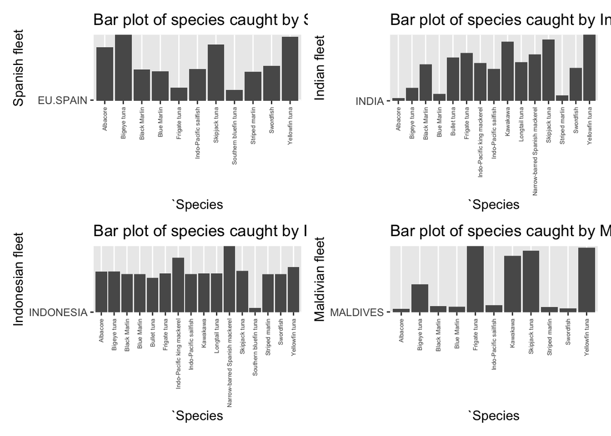

## How many of each species are caught?

To analyse this I will plot the number of catches against species type, plotting number of catches on the y axis against the species type.

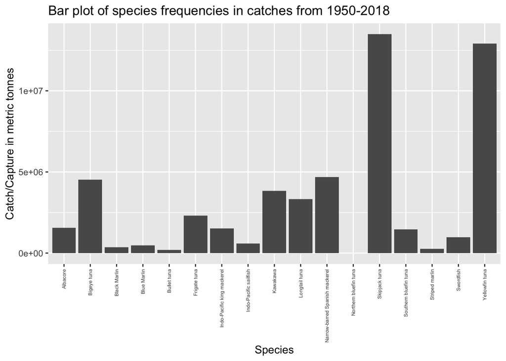

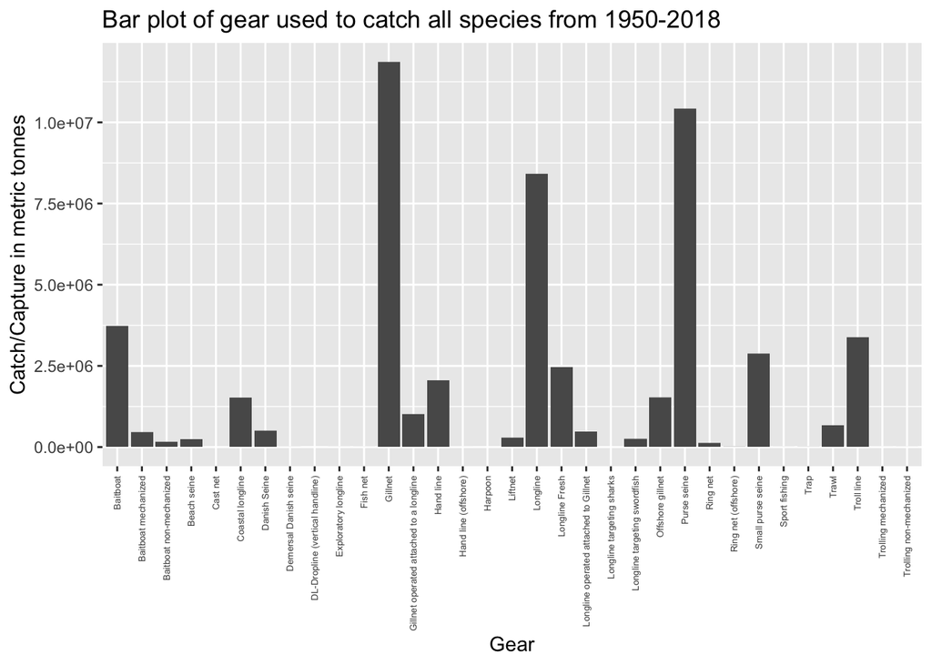

Upon observation the most frequently used gear types are ‘Gillet’, ‘Purse seine’ and ‘Longline’. I now want to see if there is any correlation between the two most caught fish (skipjack tuna and yellow tuna) and the ‘Gillet’ gear.

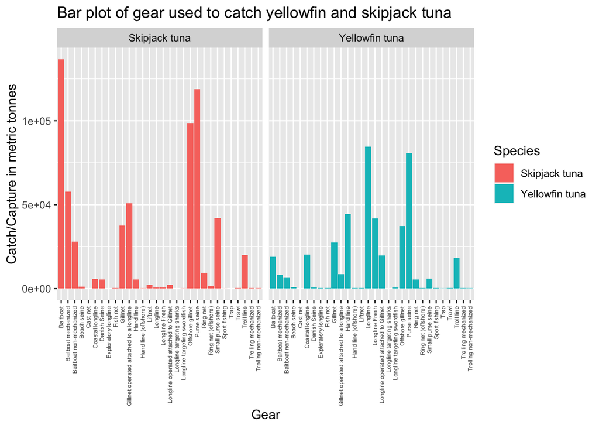

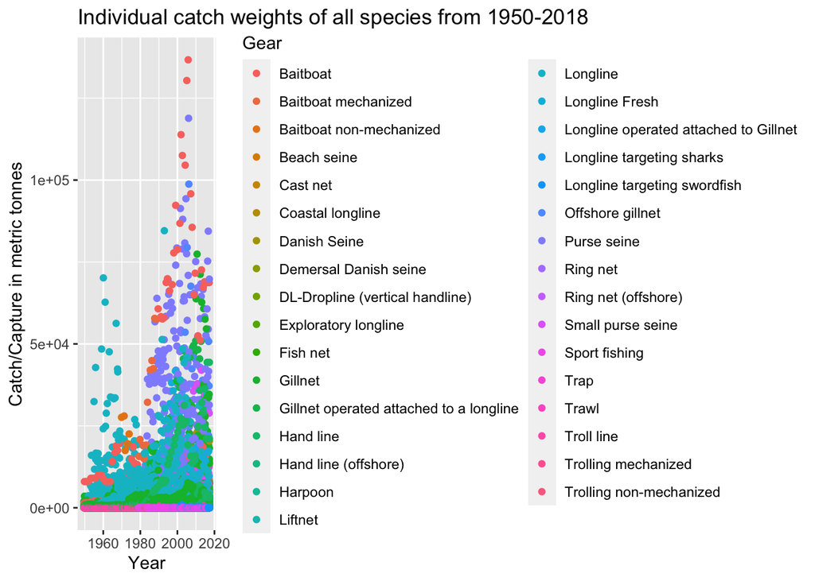

We can see that some gear types such as handlines and harpoons have been used fairly consistently (yielding median catches) over the time frame, in comparison to types such as baitboats where they have been more frequently used in the 21st century, implying that the industrialisation and commercialisation of fishing practices have changed the way that fish are caught.

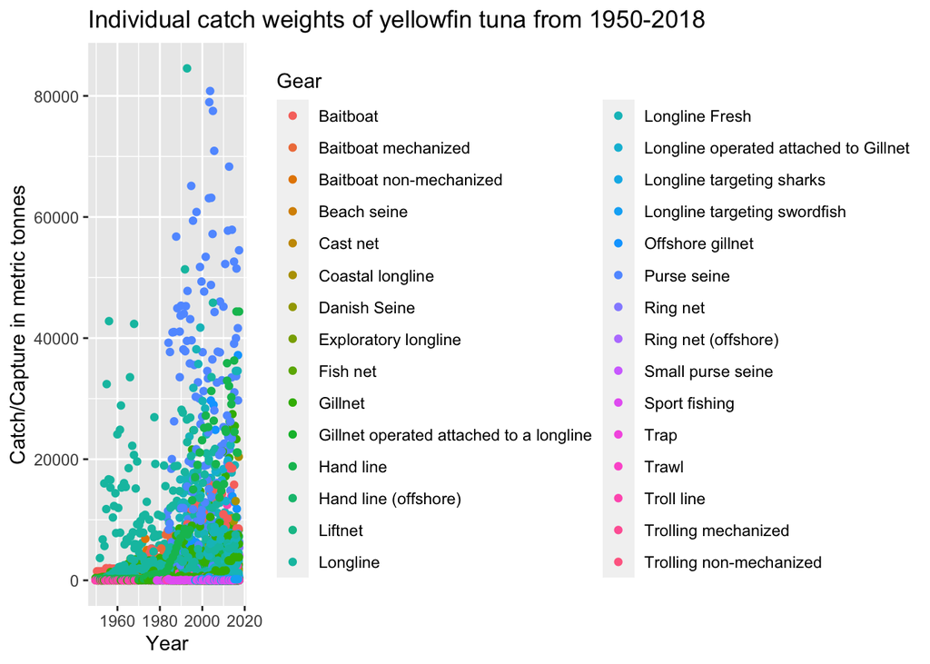

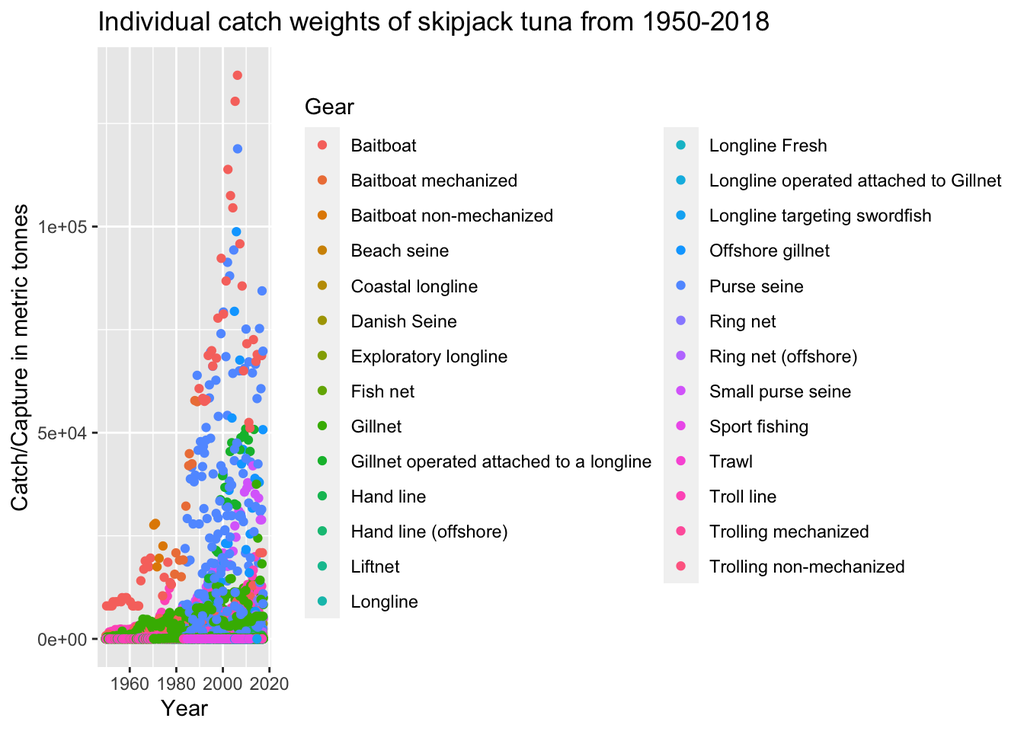

The gear type used most frequently when fishing for skipjack tuna is ‘Baitboat’ and ‘Purse Seine’, both of which yield quite high catches. However the purse seine has only been used since 1980 in comparison to baitboats which have been used throughout the time frame.